# Biological QA (mod’ed from Charlotte Soneson’s)

Nicolas Delhomme, mod’ed from Charlotte Soneson’s

2021-03-04

# 1 Setup

Here we load the needed libraries we will need for the analysis and set some graphical parameters.

- Libraries

```r
suppressPackageStartupMessages({
  library(DESeq2)
  library(edgeR)
  library(here)
  library(LSD)
  library(RColorBrewer)
  library(SummarizedExperiment)
  library(tidyverse)
  library(tximport)
  library(vsn)
})
```

- Graphics

```r
pal <- brewer.pal(8,"Dark2")
```

# 2 Introduction

In this tutorial we walk through a gene-level RNA-seq differential expression analysis using Bioconductor packages. We start from the gene-vs-sample count matrix, and thus assume that the raw reads have already been quality controlled and that the gene expression has been quantified (either using alignment and counting, or by applying an alignment-free quantification tool). We perform exploratory data analysis (EDA) for quality assessment and to explore the relationship between samples, then perform differential gene expression analysis, and visually explore the results.

Bioconductor has many packages supporting analysis of high-throughput sequence data, including RNA-seq. The packages that we will use in this tutorial include core packages maintained by the [Bioconductor core team](https://www.bioconductor.org/about/core-team/) for importing and processing raw sequencing data and loading gene annotations. We will also use contributed packages for statistical analysis and visualization of sequencing data. Through scheduled releases every 6 months, the Bioconductor project ensures that all the packages within a release will work together in harmony (hence the “conductor” metaphor). The packages used in this tutorial are loaded with the library function and can be installed by following the [Bioconductor package installation instructions](http://bioconductor.org/install/#install-bioconductor-packages).

Many parts of this tutorial are based on parts of a published RNA-seq workflow available via [F1000Research](http://f1000research.com/articles/4-1070) (Love et al. 2015) and as a [Bioconductor package](https://www.bioconductor.org/packages/release/workflows/html/rnaseqGene.html).

## 2.1 Citing scientific research software

If you use the results from an R package in published research, you can find the proper citation for the software by typing `citation("pkgName")`, where you would substitute the name of the package for `pkgName`. Citing methods papers helps to support and reward the individuals who put time into open source software for genomic data analysis.

## 2.2 Experimental data

The data used in this workflow comes from an RNA-seq experiment conducted in *Norway spruce* investigating the zygotic embryo development whereby a seed constituting of two tissues, the embryo and it’s supporting megagametophyte, develops in to a plantlet. Out of the eight time points available in the original (unpublished as of yet, but hopefully soon) studies, we have selected two: **B4** and **B8**. Hence, we have 12 samples, three biological replicates per time point and tissue (**ZE** or **FMG**, zygotic and female megagametophyte, respectively). The rationale for the studies is to compare it to the process used by the forestry industry, called *somatic embryogenesis* that is used to regenerate an embryo from a somatic tissue.

We start by setting the path to the folder containing the data that will be used in the workflow.

```r
datadir <- here("data")
```

That directory contains gene- and transcript-level quantifications for the samples in this experiment, as well as a metadata table indicating the identity of the samples. All analyses are based on the Norway spruce reference genome (v1.0) and the corresponding annotation. The types of available quantifications are:

- featureCounts: gene-level read counts obtained by featureCounts (Liao, Smyth, and Shi 2014) from the Rsubread package, following alignment by STAR (Dobin et al. 2013).
- salmon: transcript-level quantifications (read counts and TPMs) obtained by Salmon (Patro et al. 2017).

The metadata.txt file contains the sample information.

## 2.3 Goal of this tutorial

Our goal in this tutorial is to bring a summary of the RNA-seq experiment into R/Bioconductor for visualization and statistical testing. We want to visualize the relationships between the samples (within and across the tissue and time), and then we want to perform statistical tests to find which genes are changing their expression due to tissue and developmental time.

# 3 Reading the metadata

First, we will read the metadata for the experiment. The two annotations of primary interest for this tutorial is `Tissue`, which represents the tissue, and `Time`, which indicates the developmental time point at which the sample was collected. There are 3 biological replicates per `Tissue` and `Time`. The sample identifier is given by the names column, and will be used to match the metadata table to the quantifications.

```r
meta <- read_tsv(file.path(datadir, "metadata.txt"),col_types=cols(.default=col_factor()))
meta
```

```
## # A tibble: 12 x 3
##    names      Time  Tissue
##    <fct>      <fct> <fct>
##  1 P11562_110 B4    FMG
##  2 P11562_111 B4    ZE
##  3 P11562_112 B4    FMG
##  4 P11562_113 B4    ZE
##  5 P11562_114 B4    FMG
##  6 P11562_115 B4    ZE
##  7 P11562_134 B8    FMG
##  8 P11562_135 B8    ZE
##  9 P11562_136 B8    FMG
## 10 P11562_137 B8    ZE
## 11 P11562_138 B8    FMG
## 12 P11562_139 B8    ZE
```

What is a factor?

The representation in R of a categorical variable.

```r
meta$Tissue
```

```
##  [1] FMG ZE  FMG ZE  FMG ZE  FMG ZE  FMG ZE  FMG ZE
## Levels: FMG ZE
```

```r
levels(meta$Tissue)
```

```
## [1] "FMG" "ZE"
```

```r
as.integer(meta$Tissue)
```

```
##  [1] 1 2 1 2 1 2 1 2 1 2 1 2
```

# 4 Summarizing an RNA-seq experiment as a count matrix

Count-based statistical methods such as DESeq2 (Love, Huber, and Anders 2014), edgeR (Robinson, McCarthy, and Smyth 2009), limma with the voom method (Law et al. 2014), DSS (Wu, Wang, and Wu 2013), EBSeq (Leng et al. 2013), BaySeq (Hardcastle and Kelly 2010) and DEXSeq (Anders, Reyes, and Huber 2012) expect input data as obtained, e.g., from RNA-seq or another high-throughput sequencing experiment in the form of a matrix of integer values, or “counts”. The value in the i-th row and the j-th column of the matrix tells how many reads (or fragments, for paired-end RNA-seq) have been assigned to feature i in sample j. For RNA-seq, a feature is typically a gene, a transcript or an exon. Analogously, for other types of assays, the rows of the matrix might correspond e.g., to binding regions (with ChIP-Seq), species of bacteria (with metagenomic datasets), or peptide sequences (with quantitative mass spectrometry).

The fact that the values in the matrix are counts of sequencing reads (in the case of single-end sequencing) or fragments (for paired-end sequencing) is important for the count-based statistical models, e.g. DESeq2 or edgeR, as only the counts allow assessing the measurement precision correctly. It is important to never provide counts that have been normalized for sequencing depth/library size to these packages, as the statistical model is most powerful when applied to counts, and is designed to account for library size differences internally.

An alternative to using actual counts of reads or fragments aligned to the genome is to use estimated counts from software that use pseudo-alignment to the transcriptome. Since these represent expected counts rather than observed counts they are not necessarily integers, and thus may need to be rounded before they are fed to the count-based pipelines.

In the sections below, we will show how to generate gene-level count matrices in R from the output of two of the most common quantification pipelines (featureCounts and Salmon).

## 4.1 featureCounts

The `featureCounts` function (from the Rsubread package) takes as input bam files resulting from read alignment to the genome, and counts the number of reads overlapping each genomic feature (here, each gene). For the purposes of this tutorial, `featureCounts` was run as follows (**DON’T RUN THIS**):

```r
library(Rsubread)
fc <- featureCounts(files = files,
                   annot.ext = gtf,
                   isGTFAnnotationFile = TRUE,
                   GTF.featureType = "exon",
                   GTF.attrType = "gene_id",
                   useMetaFeatures = TRUE,
                   strandSpecific = 0,
                   isPairedEnd = TRUE,
                   nthreads = 6)
```

where `files` is a vector of file names pointing to the bam files for the different samples, and `gtf` points to a gtf file with the genomic regions corresponding to each gene. `featureCounts` returns a list with several element, one of which is the estimated count matrix. For simplicity, we saved the list output from the command above to a file and here we just load it back into R.

```r
fc <- readRDS(file.path(datadir, "featureCounts/star_featureCounts.rds"))
names(fc)
```

```
## [1] "counts"     "annotation" "targets"    "stat"
```

```r
counts_featurecounts <- fc$counts
colnames(counts_featurecounts) <- sub("_S.*","",colnames(counts_featurecounts))
head(counts_featurecounts)
```

```
##                  P11562_110 P11562_111 P11562_112 P11562_113 P11562_114
## MA_10g0010                0          2          0          0          0
## MA_10000213g0010          0          0          0          0          0
## MA_10000405g0010          0          0          0          0          0
## MA_1000049g0010           0          0          0          0          0
## MA_10000516g0010          0          0          0          0          0
## MA_10001g0010             0          0          0          0          0
##                  P11562_115 P11562_134 P11562_135 P11562_136 P11562_137
## MA_10g0010                0          0          0          0          0
## MA_10000213g0010          0          0          0          0          0
## MA_10000405g0010          0          0          0          0          0
## MA_1000049g0010           0          0          0          0          0
## MA_10000516g0010          0          0          0          0          0
## MA_10001g0010             0          0          0          0          0
##                  P11562_138 P11562_139
## MA_10g0010                0          0
## MA_10000213g0010          0          0
## MA_10000405g0010          0          0
## MA_1000049g0010           0          0
## MA_10000516g0010          0          0
## MA_10001g0010             0          0
```

```r
dim(counts_featurecounts)
```

```
## [1] 70736    12
```

```r
colnames(fc$stat) <- sub("_S.*","",colnames(fc$stat))
fc$stat[,1:2]
```

```
##                           Status P11562_110
## 1                       Assigned     105559
## 2            Unassigned_Unmapped          0
## 3           Unassigned_Read_Type          0
## 4           Unassigned_Singleton          0
## 5      Unassigned_MappingQuality          0
## 6             Unassigned_Chimera          0
## 7      Unassigned_FragmentLength          0
## 8           Unassigned_Duplicate          0
## 9        Unassigned_MultiMapping          0
## 10          Unassigned_Secondary          0
## 11           Unassigned_NonSplit          0
## 12         Unassigned_NoFeatures      24993
## 13 Unassigned_Overlapping_Length          0
## 14          Unassigned_Ambiguity        300
```

Let us visualise it

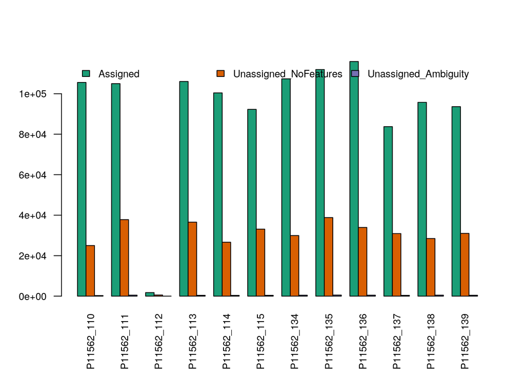

```r
stats <- as.matrix(fc$stat %>% column_to_rownames("Status"))
colnames(stats) <- sub("_S.*","",colnames(stats))
barplot(stats[rowSums(stats)>0,],
        beside = TRUE,col = pal[1:3],las=2,
        cex.axis = .8,cex.names = .8,
        legend.text = rownames(stats)[rowSums(stats)>0],
        args.legend = list(horiz=TRUE,cex=.8,x="top",bty="n"))
```

## 4.2 Alignment-free quantification

Alignment-free transcript quantification software such as kallisto (Bray et al. 2016), Salmon (Patro et al. 2017) and Sailfish (Patro, Mount, and Kingsford 2014), as well as other transcript quantification methods like Cufflinks (Trapnell et al. 2010, 2013) and RSEM (Li and Dewey 2011), differ from the counting methods covered above in that they provide quantifications (usually both as counts and as TPMs) for each transcript. These can then be summarized on the gene level by adding all values for transcripts from the same gene. A simple way to import results from these packages into R is provided by the tximport and tximeta packages. Here, `tximport` reads the quantifications into a list of matrices, and `tximeta` aggregates the information into a `SummarizedExperiment` object, and also automatically adds additional annotations for the features. Both packages can return quantifications on the transcript level or aggregate them on the gene level. They also calculate average transcript lengths for each gene and each sample, which can be used as offsets to improve the differential expression analysis by accounting for differential isoform usage across samples (Soneson, Love, and Robinson 2015).

### 4.2.1 Salmon

The code below imports the Salmon quantifications into R using the `tximport` package. Using the `txmeta` package would require us to work with an organism for which the annotation would be available from the bioconductor project (unlikely for non-model organism).

```r
# List all quant.sf output files from Salmon
salmonfiles <- file.path(datadir, "salmon", meta$names,"quant.sf")
names(salmonfiles) <- meta$names
stopifnot(all(file.exists(salmonfiles)))
```

The Norway spruce annotation have only one transcript per gene, as such there is not need to summarise the expression at the gene level, which would require the use of the `tx2gene` argument instead of `txOut`. The `tx2gene` expects a tab delimited file with the transcript ID and the corresponding gene ID it two columns.

```r
sg <- tximport(files=salmonfiles,type="salmon",txOut=TRUE)
```

```
## reading in files with read_tsv
```

```
## 1 2 3 4 5 6 7 8 9 10 11 12
```

Note that *Salmon* returns *estimated* counts, which are not necessarily integers. They may need to be rounded before they are passed to count-based statistical methods (e.g. *DESeq2*). To obtain consistent results with different pipelines, we round the estimated counts here and use the resulting matrix as input also to edgeR.

```r
counts_salmon <- round(sg$counts)
rownames(counts_salmon) <- sub("\\.1$","",rownames(counts_salmon))
```

## 4.3 Comparison of counts

For illustration, we compare the counts obtained by the two quantification approaches for the first sample. As we can see, there is an overall good correspondence between the different methods, especially for the genes with high counts.

```r
spl <- "P11562_110"
```

for comparing, we need to make sure, both counts table are sorted in the same way. We create a data.frame containing both sorted according to their gene IDs

```r
gns <- sort(intersect(rownames(counts_salmon),rownames(counts_featurecounts)))
quants <- data.frame(featureCounts = counts_featurecounts[gns, spl],
                     salmon = counts_salmon[gns, spl])

head(quants[order(quants$salmon,decreasing=TRUE),])
```

```
##                featureCounts salmon
## MA_67677g0010           7152   6146
## MA_39524g0010           5526   5566
## MA_230927g0010          7769   4219
## MA_646308g0010          3717   2890
## MA_191233g0010          3736   2652
## MA_17765g0020           4175   2503
```

Let us plot the raw counts

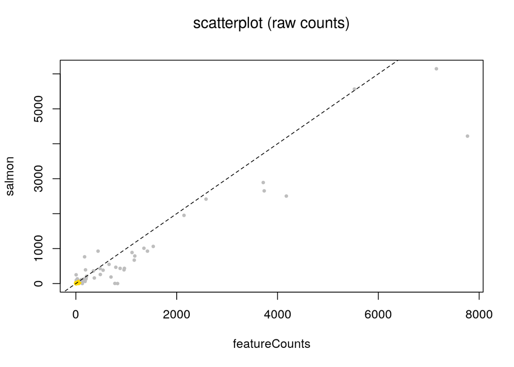

```r
heatscatter(quants$featureCounts,quants$salmon,
            xlab="featureCounts",ylab="salmon",
            main="scatterplot (raw counts)")
abline(0,1,lty=2,col="black")
```

Let us go onto a log scale

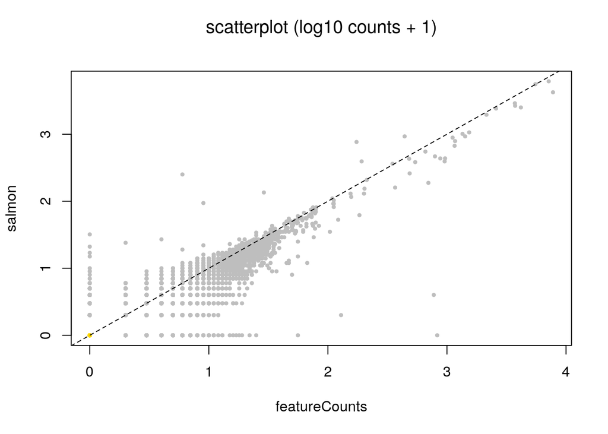

```r
heatscatter(log10(quants$featureCounts+1),log10(quants$salmon+1),
            xlab="featureCounts",ylab="salmon",
            main="scatterplot (log10 counts + 1)")
abline(0,1,lty=2,col="black")
```

# 5 Representing counts for differential expression packages

At this point, we have a gene-level count matrix. In the rest of this tutorial, we will work with the counts generated by `Salmon` and imported into R with `tximport`. This is a branching point where we could use a variety of Bioconductor packages for exploration and differential expression of the count matrix, including edgeR (Robinson, McCarthy, and Smyth 2009), DESeq2 (Love, Huber, and Anders 2014), limma with the voom method (Law et al. 2014), DSS (Wu, Wang, and Wu 2013), EBSeq (Leng et al. 2013) and BaySeq (Hardcastle and Kelly 2010). We will continue using `DESeq2` and `edgeR`. Why? Because you are likely to encounter both in the literature.

Differences? Little - mostly taste. `DESeq2` abstracts a lot of the decisions from the user, while `edgeR` leave these all to the user.

Bioconductor software packages often define and use a custom class for storing data that makes sure that all the needed data slots are consistently provided and fulfill any requirements. In addition, Bioconductor has general data classes (such as the `SummarizedExperiment`) that can be used to move data between packages. The DEFormats package can be useful for converting between different classes. The core Bioconductor classes also provide useful functionality: for example, subsetting or reordering the rows or columns of a `SummarizedExperiment` automatically subsets or reorders the associated `rowRanges` and `colData`, which can help to prevent accidental sample swaps that would otherwise lead to spurious results. With `SummarizedExperiment` this is all taken care of behind the scenes.

Each of the packages we will use for differential expression has a specific class of object used to store the summarization of the RNA-seq experiment and the intermediate quantities that are calculated during the statistical analysis of the data. `DESeq2` uses a `DESeqDataSet` and `edgeR` uses a `DGEList`.

## 5.1 The DESeqDataSet, sample information, and the design formula

In `DESeq2`, the custom class is called `DESeqDataSet`. It is built on top of the `SummarizedExperiment` class, and it is easy to convert `SummarizedExperiment` objects into `DESeqDataSet` objects. One of the two main differences compared to a `SummarizedExperiment` object is that the `assay` slot is instead accessed using the `counts` accessor function, and the `DESeqDataSet` class enforces that the values in this matrix are non-negative integers.

A second difference is that the `DESeqDataSet` has an associated *design formula*. The experimental design is specified at the beginning of the analysis, as it will inform many of the `DESeq2` functions how to treat the samples in the analysis (one exception is the size factor estimation, i.e., the adjustment for differing library sizes, which does not depend on the design formula). The design formula tells which columns in the sample information table (`colData`) specify the experimental design and how these factors should be used in the analysis.

Let’s remind ourselves of the design of our experiment: Let us take a look at the information we have about our samples to build our model

```r
meta <- meta %>% column_to_rownames("names")
meta
```

```
##            Time Tissue
## P11562_110   B4    FMG
## P11562_111   B4     ZE
## P11562_112   B4    FMG
## P11562_113   B4     ZE
## P11562_114   B4    FMG
## P11562_115   B4     ZE
## P11562_134   B8    FMG
## P11562_135   B8     ZE
## P11562_136   B8    FMG
## P11562_137   B8     ZE
## P11562_138   B8    FMG
## P11562_139   B8     ZE
```

Time and Tissue are the two categorical variables of interest

```r
meta$Time
```

```
##  [1] B4 B4 B4 B4 B4 B4 B8 B8 B8 B8 B8 B8
## Levels: B4 B8
```

```r
meta$Tissue
```

```
##  [1] FMG ZE  FMG ZE  FMG ZE  FMG ZE  FMG ZE  FMG ZE
## Levels: FMG ZE
```

Both are factors (categorical variables), and based on the order of the levels, B4 and FMG will be the reference we compare to (*i.e.* B4 FMG will be our expression baseline) Some sanity checking

```r
stopifnot(all(colnames(counts_salmon) == rownames(meta)))
```

Let us create the DESeq objects. Using the method `DESeqDataSetFromTximport` make sure to take into account the observed transcript length as a representation of a potential differential isoform usage (*i.e.* setting an offset), which is the point of the tximport methods (Soneson, Love, and Robinson 2015) for gene-level analysis. See [there](https://bioconductor.org/packages/release/bioc/vignettes/tximport/inst/doc/tximport.html#downstream-dge-in-bioconductor).

```r
ds_se <- DESeqDataSetFromTximport(txi=sg,
                                colData=meta ,
                                design = ~ Tissue * Time)
```

```
## using counts and average transcript lengths from tximport
```

Before proceeding, we know that sample `P11562_112` is undersampled. to prevent it from biasing our further processing we remove it, as well as the corresponding metadata.

```r
sel <- rownames(meta) != "P11562_112"
ds_se <- ds_se[,sel]
counts_salmon <- counts_salmon[,sel]
meta <- meta[sel,]
```

## 5.2 The DGEList

As mentioned above, the edgeR package uses another type of data container, namely a `DGEList` object. It is just as easy to create a `DGEList` object using a count matrix and a table with information about samples. We can additionally add information about the genes. Here we illustrate how to generate a `DGEList` object from the Salmon count matrix. Create the object

```r
genetable <- data.frame(gene.id = rownames(counts_salmon),
                        stringsAsFactors = FALSE)
stopifnot(all(rownames(meta) == colnames(counts_salmon)))
dge <- DGEList(counts = counts_salmon,
               samples = meta,
               genes = genetable)
names(dge)
```

```
## [1] "counts"  "samples" "genes"
```

Just like the `SummarizedExperiment` and the `DESeqDataSet` the `DGEList` contains all the information we need: the count matrix, information about the samples (the columns of the count matrix), and information about the genes (the rows of the count matrix). One difference compared to the `DESeqDataSet` is that the experimental design is not defined when creating the `DGEList`, but later in the workflow.

To include information about the average transcript lengths (offsets) estimated by `tximport` in `edgeR`, the offsets must be added manually. The `tximport` vignette shows how this is done, and we repeat it here.

Here is an illustration of what I meant earlier, `edgeR` leaves a lot for the user to do

Here we retrieve the average transcript length, use it to correct the salmon expression values, before calculating the library size factor (*i.e.* the difference in sequencing depth between samples).

```r
avetxlengths <- sg$length[,sel]
rownames(avetxlengths) <- sub("\\.1$","",rownames(avetxlengths))
stopifnot(all(rownames(avetxlengths) == rownames(counts_salmon)))
stopifnot(all(colnames(avetxlengths) == colnames(counts_salmon)))
avetxlengths <- avetxlengths/exp(rowMeans(log(avetxlengths)))
offsets <- log(calcNormFactors(counts_salmon/avetxlengths)) +
  log(colSums(counts_salmon/avetxlengths))
dge <- scaleOffset(dge, t(t(log(avetxlengths)) + offsets))
names(dge)
```

```
## [1] "counts"  "samples" "genes"   "offset"
```

Once a DGEList has been created, we calculate between-sample (TMM) normalization factors, using the `calcNormFactors` function in edgeR.

```r
dge <- edgeR::calcNormFactors(dge)
dge$samples
```

```
##            group lib.size norm.factors Time Tissue
## P11562_110     1    77681    0.7397357   B4    FMG
## P11562_111     1    71962    1.1439251   B4     ZE
## P11562_113     1    69087    1.0584330   B4     ZE
## P11562_114     1    75411    0.7932304   B4    FMG
## P11562_115     1    69126    1.1342835   B4     ZE
## P11562_134     1    75348    0.9713382   B8    FMG
## P11562_135     1    71606    1.1305120   B8     ZE
## P11562_136     1    74515    0.9341361   B8    FMG
## P11562_137     1    67740    1.1350438   B8     ZE
## P11562_138     1    73956    0.9523384   B8    FMG
## P11562_139     1    70011    1.1191332   B8     ZE
```

Let us visualise the library size factor differences

It is very similar across all samples varying from -25% to +15%

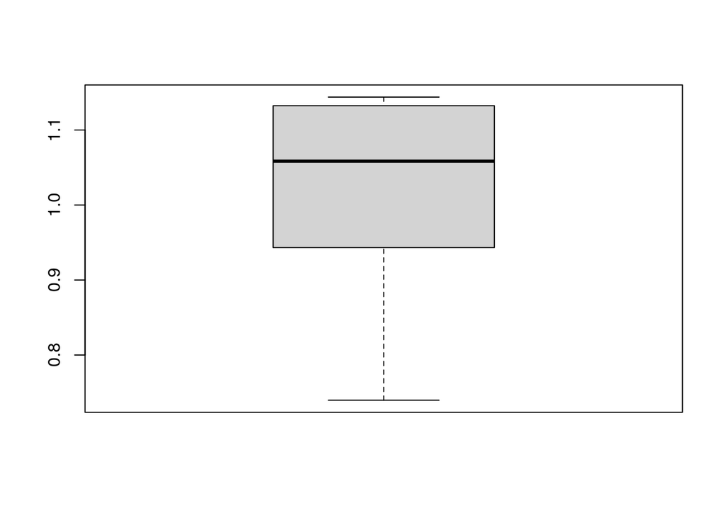

```r
boxplot(dge$samples$norm.factors)
```

In the remainder of this tutorial, we will use the `ds_se` and `dge` objects for `DESeq2` and `edgeR` analyses, respectively.

# 6 Exploratory analysis and visualization

There are two separate analysis paths in this tutorial:

1. visual exploration of sample relationships, in which we will discuss transformation of the counts for computing distances or making plots
2. statistical testing for differences attributable to tissue and time

Importantly, **the statistical testing methods rely on original count data (not scaled or transformed)** for calculating the precision of measurements. However, for visualization and exploratory analysis, transformed counts are typically more suitable. Thus, it is critical to separate the two workflows and use the appropriate input data for each of them.

## 6.1 Transformations

Many common statistical methods for exploratory analysis of multidimensional data, for example clustering and *principal components analysis* (PCA), work best for data that generally has the same range of variance at different ranges of the mean values. When the expected amount of variance is approximately the same across different mean values, the data is said to be *homoskedastic*. For RNA-seq raw counts, however, the variance grows with the mean. For example, if one performs PCA directly on a matrix of size-factor-normalized read counts, the result typically depends only on the few most strongly expressed genes because they show the largest absolute differences between samples. A simple and often used strategy to avoid this is to take the logarithm of the normalized count values plus a small pseudocount; however, now the genes with the very lowest counts will tend to dominate the results because, due to the strong Poisson noise inherent to small count values, and the fact that the logarithm amplifies differences for the smallest values, these low count genes will show the strongest relative differences between samples.

As a solution, `DESeq2` offers transformations for count data that stabilize the variance across the mean: the `regularized logarithm` (rlog) and the `variance stabilizing transformation` (VST). These have slightly different implementations, discussed a bit in the `DESeq2` paper and in the vignette, but a similar goal of stabilizing the variance across the range of values. Both produce log2-like values for high counts. Here we will use the variance stabilizing transformation implemented with the `vst` function.

Neither `DESeq2` nor `edgeR` modify the count data. They calculate the parameters (such as the library size factor, the dispersion, etc.) to use in their model. If we want to visualise the data in a reduced dimensionality (not 50+ thousands genes and x samples as a matrix), such as a PCA (principal component analysis), or MDS (Multi-dimensional scaling), we need to normalise the data.

In addition to a difference in sequencing depth between samples, RNA-Seq data suffers from another problem, a mean-variance relationship, *i.e.* the data is heteroskedastic.

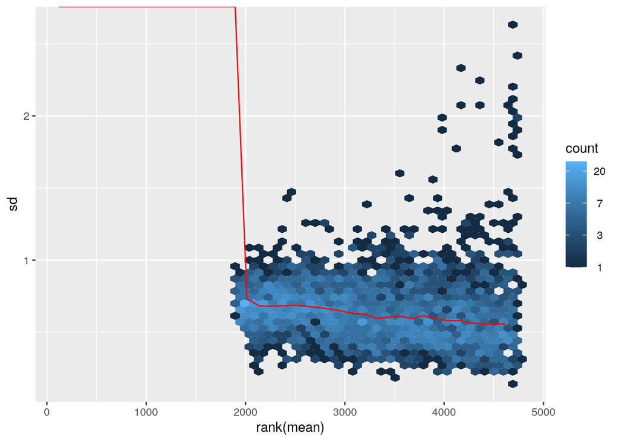

```r
meanSdPlot(log(assay(ds_se)[rowSums(assay(ds_se))>30,]))
```

To counteract this, one can use a variance stabilising transformation (VST), a heuristic that will transform the variance so it becomes independent of the mean

```r
vsd <- DESeq2::vst(ds_se)
```

```
## using 'avgTxLength' from assays(dds), correcting for library size
```

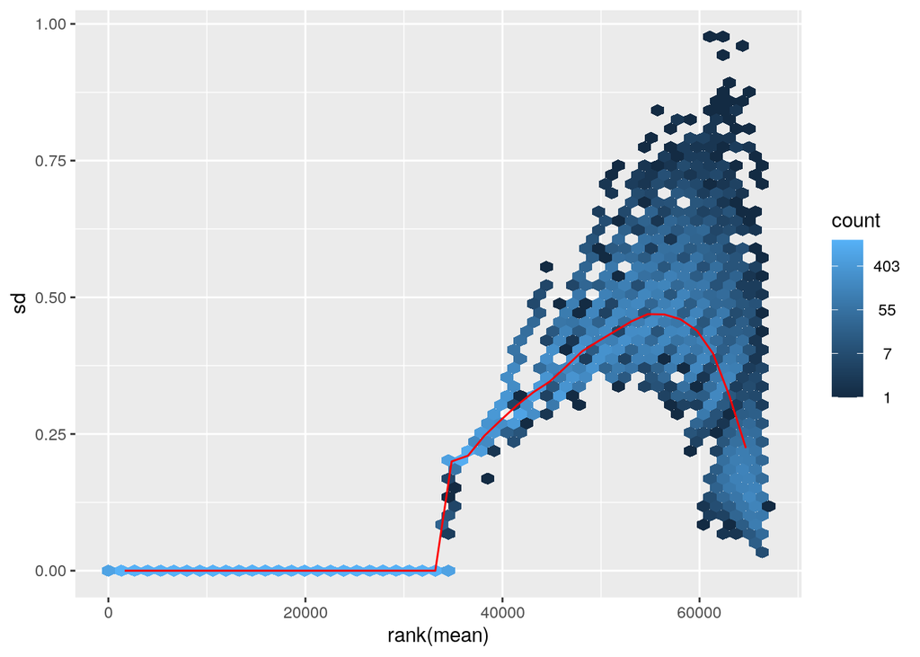

```r
meanSdPlot(log(assay(vsd)[rowSums(assay(vsd))>0,]))
```

## 6.2 PCA plot

One way to visualize sample-to-sample distances is a principal components analysis (PCA). In this ordination method, the data points (here, the samples) are projected onto the 2D plane such that they spread out in the two directions that explain most of the differences (Figure below). The x-axis (the first principal component, or PC1) is the direction that separates the data points the most (*i.e.*, the direction with the largest variance). The y-axis (the second principal component, or PC2) represents the direction with largest variance subject to the constraint that it must be orthogonal to the first direction. The percent of the total variance that is contained in the direction is printed in the axis label. Note that these percentages do not sum to 100%, because there are more dimensions that contain the remaining variance (although each of these remaining dimensions will explain less than the two that we see).

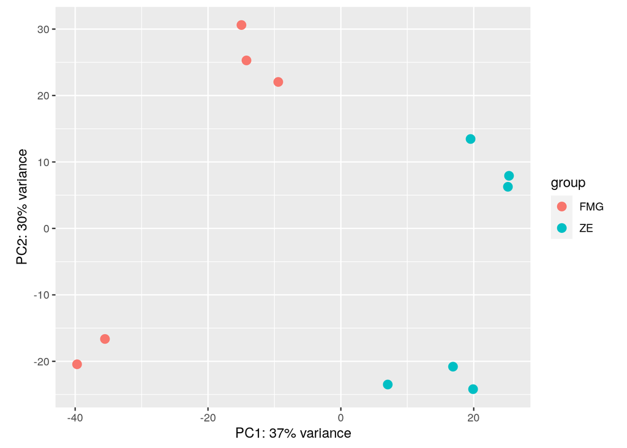

```r
DESeq2::plotPCA(vsd, intgroup = "Tissue")
```

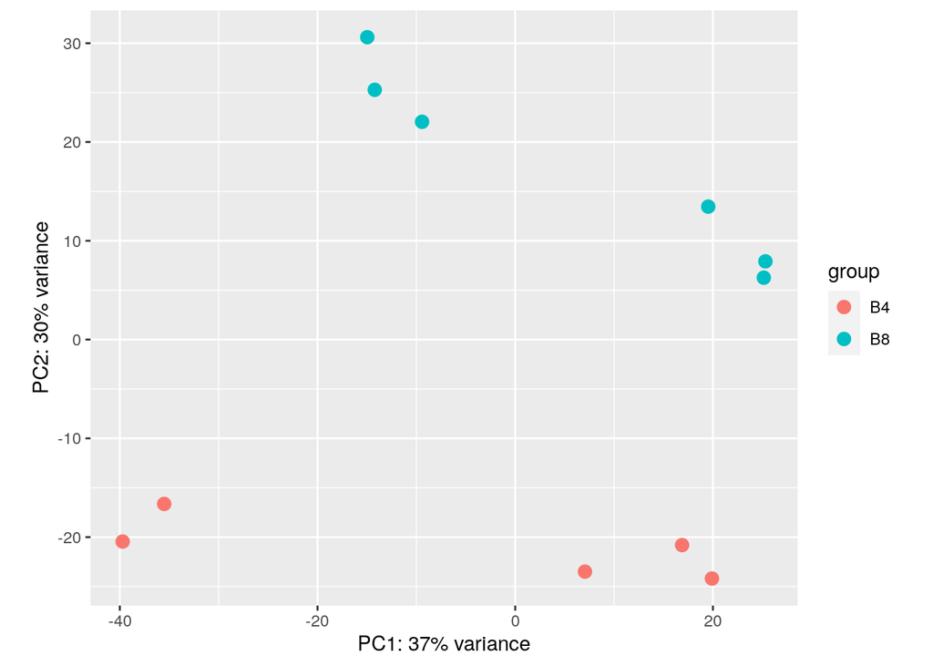

```r
DESeq2::plotPCA(vsd, intgroup = "Time")
```

## 6.3 MDS plot

Another way to reduce dimensionality, which is in many ways similar to PCA, is multidimensional scaling (MDS). For MDS, we first have to calculate all pairwise distances between our objects (samples in this case), and then create a (typically) two-dimensional representation where these pre-calculated distances are represented as accurately as possible. This means that depending on how the pairwise sample distances are defined, the two-dimensional plot can be very different, and it is important to choose a distance that is suitable for the type of data at hand.

`edgeR` contains a function `plotMDS`, which operates on a `DGEList` object and generates a two-dimensional MDS representation of the samples. The default distance between two samples can be interpreted as the “typical” log fold change between the two samples, for the genes that are most different between them (by default, the top 500 genes, but this can be modified). We generate an MDS plot from the DGEList object dge, coloring by the time and using different plot symbols for different tissue.

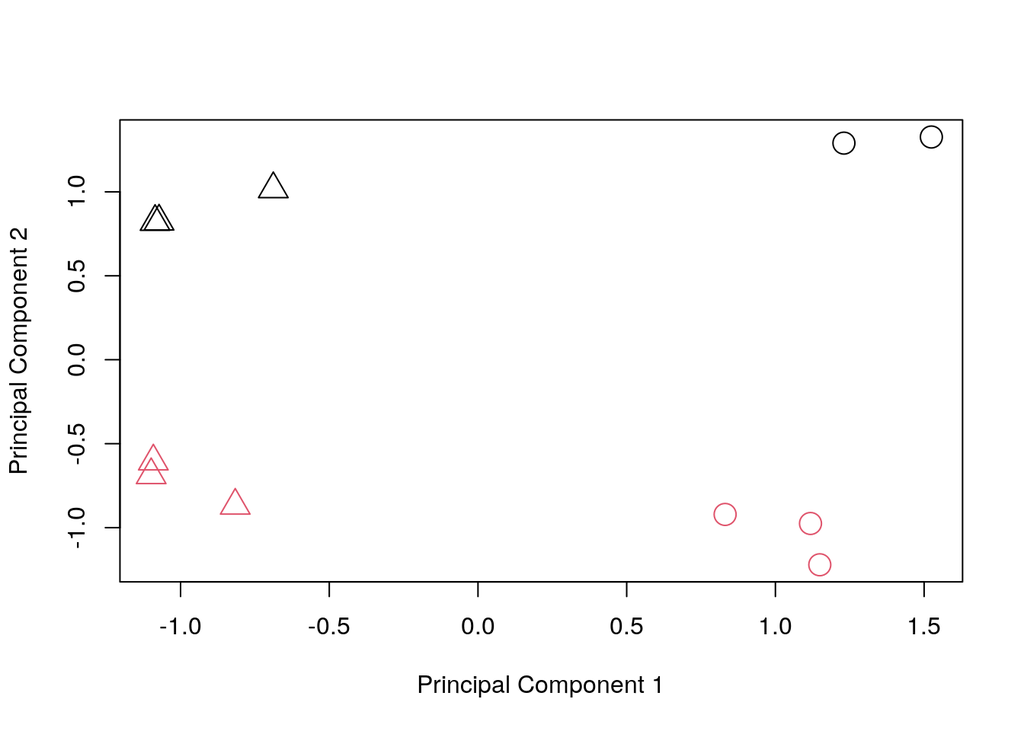

```r
plotMDS(dge, top = 500,
        labels = NULL,
        col = as.numeric(dge$samples$Time),
        pch = as.numeric(dge$samples$Tissue),
        cex = 2, gene.selection = "common")
```

## 6.4 Let us export the results for the next step

```r
rownames(ds_se) <- sub("\\.1","",rownames(ds_se))
dir.create(file.path(datadir,"DE"),showWarnings=FALSE)
save(ds_se,dge,vsd,file=file.path(datadir,"DE","differentialExpressionObjects.rda"))
```

# 8 References

Anders, Simon, Alejandro Reyes, and Wolfgang Huber. 2012. “Detecting Differential Usage of Exons from RNA-seq Data.” Genome Res. 22 (10): 2008–17.

Benjamini, Yoav, and Yosef Hochberg. 1995. “Controlling the False Discovery Rate: A Practical and Powerful Approach to Multiple Testing.” Journal of the Royal Statistical Society. Series B (Methodological) 57 (1): 289–300. http://www.jstor.org/stable/2346101.

Bray, Nicolas L, Harold Pimentel, Páll Melsted, and Lior Pachter. 2016. “Near-Optimal RNA-Seq Quantification.” Nat. Biotechnol.

Dobin, Alexander, Carrie A. Davis, Felix Schlesinger, Jorg Drenkow, Chris Zaleski, Sonali Jha, Philippe Batut, Mark Chaisson, and Thomas R. Gingeras. 2013. “STAR: ultrafast universal RNA-seq aligner.” Bioinformatics 29 (1). Oxford University Press: 15–21. https://doi.org/10.1093/bioinformatics/bts635.

Dudoit, Sandrine, Yee H. Yang, Matthew J. Callow, and Terence P. Speed. 2002. “Statistical methods for identifying differentially expressed genes in replicated cDNA microarray experiments.” In Statistica Sinica, 111–39. http://citeseerx.ist.psu.edu/viewdoc/summary?doi=10.1.1.117.9702.

Hardcastle, Thomas, and Krystyna Kelly. 2010. “baySeq: Empirical Bayesian methods for identifying differential expression in sequence count data.” BMC Bioinformatics 11 (1): 422+. https://doi.org/10.1186/1471-2105-11-422.

Himes, Blanca E., Xiaofeng Jiang, Peter Wagner, Ruoxi Hu, Qiyu Wang, Barbara Klanderman, Reid M. Whitaker, et al. 2014. “RNA-Seq transcriptome profiling identifies CRISPLD2 as a glucocorticoid responsive gene that modulates cytokine function in airway smooth muscle cells.” PloS One 9 (6). https://doi.org/10.1371/journal.pone.0099625.

Law, Charity W., Yunshun Chen, Wei Shi, and Gordon K. Smyth. 2014. “Voom: precision weights unlock linear model analysis tools for RNA-seq read counts.” Genome Biology 15 (2). BioMed Central Ltd: R29+. https://doi.org/10.1186/gb-2014-15-2-r29.

Leng, N., J. A. Dawson, J. A. Thomson, V. Ruotti, A. I. Rissman, B. M. G. Smits, J. D. Haag, M. N. Gould, R. M. Stewart, and C. Kendziorski. 2013. “EBSeq: an empirical Bayes hierarchical model for inference in RNA-seq experiments.” Bioinformatics 29 (8). Oxford University Press: 1035–43. https://doi.org/10.1093/bioinformatics/btt087.

Li, Bo, and Colin N. Dewey. 2011. “RSEM: accurate transcript quantification from RNA-Seq data with or without a reference genome.” BMC Bioinformatics 12: 323+. https://doi.org/10.1186/1471-2105-12-3231.

Liao, Y., G. K. Smyth, and W. Shi. 2014. “featureCounts: an efficient general purpose program for assigning sequence reads to genomic features.” Bioinformatics 30 (7). Oxford University Press: 923–30. https://doi.org/10.1093/bioinformatics/btt656.

Love, Michael I., Simon Anders, Vladislav Kim, and Wolfgang Huber. 2015. “RNA-Seq Workflow: Gene-Level Exploratory Analysis and Differential Expression.” F1000Research, October. https://doi.org/10.12688/f1000research.7035.1.

Love, Michael I., Wolfgang Huber, and Simon Anders. 2014. “Moderated estimation of fold change and dispersion for RNA-seq data with DESeq2.” Genome Biology 15 (12). BioMed Central Ltd: 550+. https://doi.org/10.1186/s13059-014-0550-8.

Patro, Rob, Geet Duggal, Michael I Love, Rafael A Irizarry, and Carl Kingsford. 2017. “Salmon Provides Fast and Bias-Aware Quantification of Transcript Expression.” Nat. Methods.

Patro, Rob, Stephen M. Mount, and Carl Kingsford. 2014. “Sailfish enables alignment-free isoform quantification from RNA-seq reads using lightweight algorithms.” Nature Biotechnology 32: 462–64. https://doi.org/10.1038/nbt.2862.

Robinson, M. D., D. J. McCarthy, and G. K. Smyth. 2009. “edgeR: a Bioconductor package for differential expression analysis of digital gene expression data.” Bioinformatics 26 (1). Oxford University Press: 139–40. https://doi.org/10.1093/bioinformatics/btp616.

Soneson, Charlotte, Michael I. Love, and Mark Robinson. 2015. “Differential analyses for RNA-seq: transcript-level estimates improve gene-level inferences.” F1000Research 4 (1521). https://doi.org/10.12688/f1000research.7563.1.

Trapnell, Cole, David G Hendrickson, Martin Sauvageau, Loyal Goff, John L Rinn, and Lior Pachter. 2013. “Differential Analysis of Gene Regulation at Transcript Resolution with RNA-seq.” Nat. Biotechnol. 31 (1): 46–53.

Trapnell, Cole, Brian a Williams, Geo Pertea, Ali Mortazavi, Gordon Kwan, Marijke J van Baren, Steven L Salzberg, Barbara J Wold, and Lior Pachter. 2010. “Transcript Assembly and Quantification by RNA-Seq Reveals Unannotated Transcripts and Isoform Switching During Cell Differentiation.” Nat. Biotechnol. 28 (5): 511–15.

Wu, Hao, Chi Wang, and Zhijin Wu. 2013. “A new shrinkage estimator for dispersion improves differential expression detection in RNA-seq data.” Biostatistics 14 (2). Oxford University Press: 232–43. https://doi.org/10.1093/biostatistics/kxs033.

Zeeberg, Barry R, Joseph Riss, David W Kane, Kimberly J Bussey, Edward Uchio, W Marston Linehan, J Carl Barrett, and John N Weinstein. 2004. “Mistaken Identifiers: Gene Name Errors Can Be Introduced Inadvertently When Using Excel in Bioinformatics.” BMC Bioinformatics 5: 80.

Ziemann, Mark, Yotam Eren, and Assam El-Osta. 2016. “Gene Name Errors Are Widespread in the Scientific Literature.” Genome Biol. 17 (1): 1–3.